# A quick analysis of Baltimore crime

#### Ben Klimkowski and Jon Fetter-Degges

What question are you asking?:

What neighborhoods have the highest number of arrests? Of narcotics arrests? What is the nature of the crime in the worst neighborhoods?

What is the code you use to answer it?:

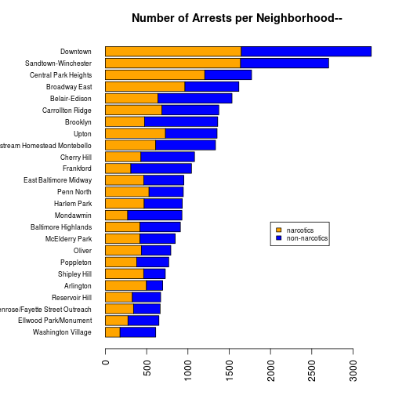

```r
# We begin by counting the total number of arrest records per neighborhood,
# throwing out those where the neighborhood is empty.
total <- table(arrest_tab$neighborhood[arrest_tab$neighborhood != ""])
# Now we do it again, using only narcotics arrests.
narc.arrests <- arrest_tab$neighborhood[grep("narcotics", arrest_tab$incidentOffense,
    ignore.case = TRUE)]
narc <- table(narc.arrests[narc.arrests != ""])
# We want to put these vectors into the same data frame, so let's throw away
# neighborhoods with no narcotics arrests.
total <- total[names(total) %in% names(narc)]
df <- data.frame(total)
df$narc <- narc
# Now we can sort the frame by total number of arrests.
df <- df[order(df$total, df$narc), ]
df$nonnarc <- df$total - df$narc
# We'll get rid of extra variables; everything we need is in the frame.
rm(total, narc, narc.arrests)
# And generate a plot of neighborhoods with the most arrests, along with how
# many of them are for narcotics.  We looked at Hui Miao's code to find out
# how to save and restore graph parameters.
old_par <- par(no.readonly = TRUE)
par(las = 2, mar = c(4, 9, 3, 2) + 0.1)
barplot(t(as.matrix(df[df$total > 600, 2:3])), horiz = TRUE, col = c("orange",
    "blue"), cex.names = 0.7, main = "Number of Arrests per Neighborhood--")
legend(2000, 12, legend = c("narcotics", "non-narcotics"), fill = c("orange",
    "blue"), cex = 0.7)
```

```r
par(old_par)

# Using the code above it, we will now create graphics for the 5
# neighborhoods with the most crime: Downtown, Sandtown-Winchester, Central
# Park Heights, Broadway East, Belair-Edison

library(plotrix)
bmoreHoodAnalyze <- function(arg1) {
    # This function cleans the Baltimore dataset by combining similar crimes and
    # and graphically depicts the most frequently crimes in an area
    a <- table(arrest_tab$incidentOffense[arrest_tab$neighborhood == arg1])
    df <- data.frame(a)

    # Combine sums Narcotics
    narcoSum <- sum(df$Freq[df$Var1 == "87O-Narcotics (Outside)" | df$Var1 ==
        "87-Narcotics"])
    df$Freq[df$Var1 == "87-Narcotics"] <- narcoSum
    df <- df[!df$Var1 == "87O-Narcotics (Outside)", ]
    ## Unlabeled crimes
    unkSum <- sum(df$Freq[df$Var1 == "Unknown Offense" | df$Var1 == "79-Other"])
    df$Freq[df$Var1 == "Unknown Offense"] <- unkSum
    df <- df[!df$Var1 == "79-Other", ]
    df <- df[!df$Var1 == "Unknown Offense", ]

    # Concatenate the remainder of the crimes
    df <- df[order(-df$Freq), ]
    l <- as.vector(df[, 1])[0:5]
    freq <- as.vector(df[, 2])[0:5]
    freq <- c(freq, sum(as.vector(df[, 2])[6:dim(df)[1]]) + unkSum)
    l <- c(l, "Other")
    title <- paste0("Distribution of Type of Crime in ", arg1)
    pie3D(freq, labels = l, explode = 0.2, theta = pi/2.5, labelcex = 0.7, main = title)
}


bmoreHoodAnalyze("Downtown")
```

```
## Error: could not find function "pie3D"
```

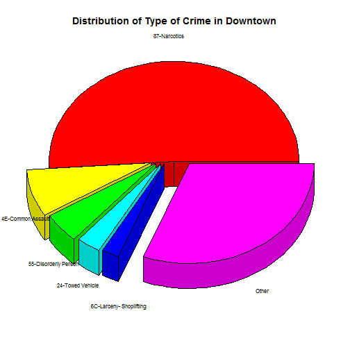

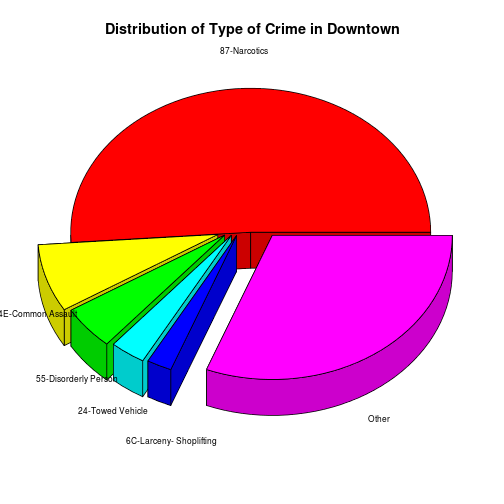

```r
bmoreHoodAnalyze("Sandtown-Winchester")
```

```
## Error: could not find function "pie3D"
```

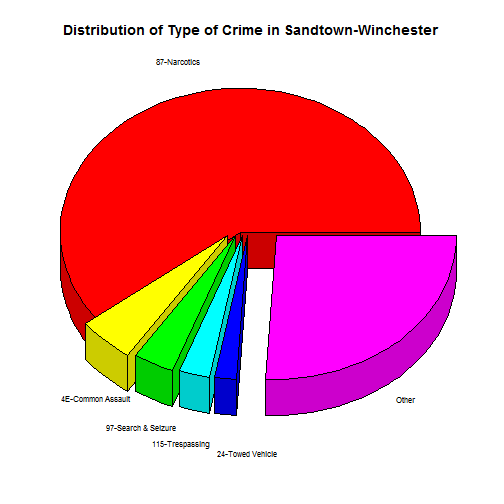

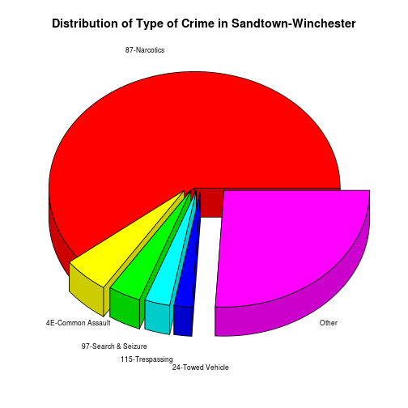

```r
bmoreHoodAnalyze("Central Park Heights")
```

```
## Error: could not find function "pie3D"
```

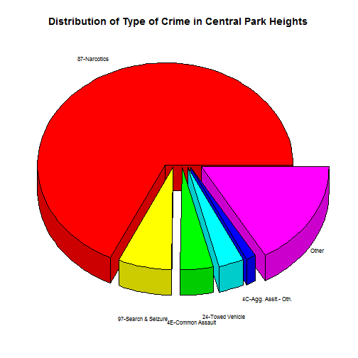

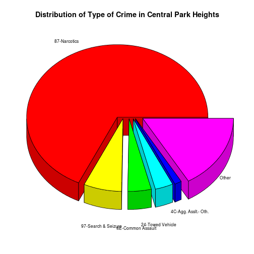

```r
bmoreHoodAnalyze("Broadway East")
```

```
## Error: could not find function "pie3D"
```

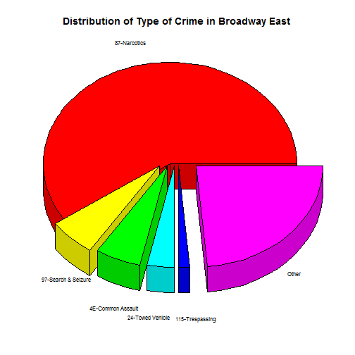

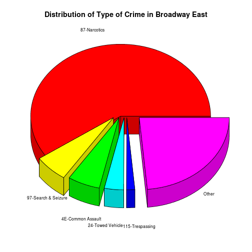

```r
bmoreHoodAnalyze("Belair-Edison")
```

```
## Error: could not find function "pie3D"
```

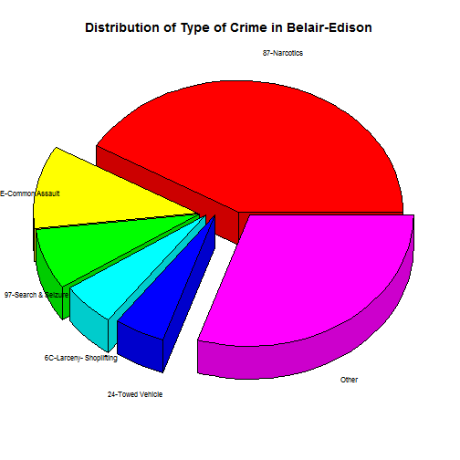

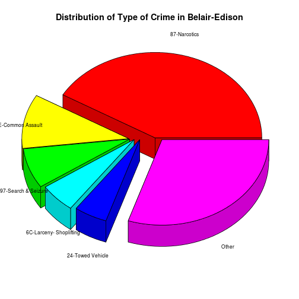

What did you observe?:

It is clear from this analysis that narcotics related crimes are the most frequent ones across many neighborhoods in Baltimore.

Unfortunately, the Baltimore database left many entries as “79-Other” or unknown, so specific crimes are hard to correlate. However, with some cleaning of the data-set, a clear pattern emerged in these problem spots. After narcotics, the most frequent crime to be encountered would be assault or search/seizure related, followed by towed vehicles.

#### Perceptrons: Victoria Cepeda, Ahmed Kosba, Mat?as Marenchino, Mohamed Gunady

What question are you asking?:

```
1. As presented earlier by another team, arrests rate on the weekend is not as high as in the middle of the week, although it was expected for crimes to be a bit more in the weekend. So Why is that?

2. How is the number of vacant houses correlated with the crime rate in a neighborhood? We are concerned with two types of crimes: 1) Violence-related. 2) Narcotic-related. We obtained a dataset for vacant buildings in Baltimore and used it to plot their locations vs. the geographical distribution of each crime category.
```

What is the code you use to answer it?:

```
Test1: Crimes on the weekend.
```

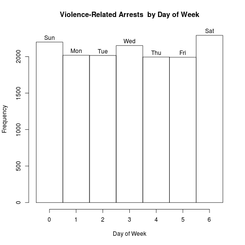

```r
# Define two types of crimes: Violence-Related, Narcotic-Related
narcotics <- c("87-Narcotics", "87O-Narcotics (Outside)", "97-Search & Seizure")
violentCrimes <- c("102-Questional Death", "104-Malicious Burning", "105-Suspicious Burning",
    "115-Trespassing", "1A-Murder", "2A-Rape (Force)", "2B-Rape (Attempt)",
    "2D-Statutory Rape", "2G-Sodomy/Perverson", "2J-Other Sex Offn.", "39-Fire",
    "3AF-Robb Hwy-Firearm", "3AJF-Robb Carjack-Firearm", "3AJK-Robb Carjack-Knife",
    "3AK-Robb Hwy-Knife", "3AO-Robb Hwy-Other Wpn", "3B-Robb Highway (Ua)",
    "3BJ-Robb Carjack(Ua)", "3CF-Robb Comm-Firearm", "3CK-Robb Comm-Knife",
    "3CO-Robb Comm-Other Wpn", "3D-Robb Comm. (Ua)", "3EF-Robb Gas Station-Firearm",
    "3EK-Robb Gas Station-Knife", "3F-Robb Gas Sta. (Ua)", "3GF-Robb Conv Store-Firearm",
    "3GK-Robb Conv Store-Knife", "3GO-Robb Conv Store-Other Wpn", "3H-Robb Conv. Stor.(Ua)",
    "3JF-Robb Residence-Firearm", "3JK-Robb Residence-Knife", "3JO-Robb Residence-Other Wpn",
    "3K-Robb Res. (Ua)", "3LF-Robb Bank-Firearm", "3FO-RObb Bank-Other Wpn",
    "3M-Robb Bank (Ua)", "3NF-Robb Misc-Firearm", "3NK-Robb Misc-Knife", "3NO-Robb Misc-Other Wpn",
    "3P-Robb Misc. (Ua)", "49-Family Disturbance", "4A-Agg. Asslt.- Gun", "4B-Agg. Asslt.- Cut",
    "4C-Agg. Asslt.- Oth.", "4D-Agg. Asslt.- Hand", "4E-Common Assault", "4F-Assault By Threat",
    "52A-Animal Cruelty", "56-Missing Person", "75-Destruct. Of Property", "76-Child Abuse-Sexual",
    "7A-Stolen Auto")

# Arrest data for the two types of crimes, and crimes with unknown offense
violent_arrests <- arrest_tab[arrest_tab$incidentOffense %in% violentCrimes,
    ]
narcotic_arrests <- arrest_tab[arrest_tab$incidentOffense %in% narcotics, ]
unknown_arrests <- arrest_tab[arrest_tab$incidentOffense == "Unknown Offense",
    ]

# Histogram function for crimes over the days of week
hist_dayofweek <- function(dataDates, dataName) {
    dates = as.Date(dataDates, "%m/%d/%Y")
    dayofweek <- format(dates, "%a")
    dayofweek_nums <- as.numeric(format(dates, "%w"))  # numeric version
    hist(dayofweek_nums, main = paste(dataName, " by Day of Week"), xlab = "Day of Week",
        ylab = "Frequency", breaks = -0.5 + 0:7, labels = unique(dayofweek[order(dayofweek_nums)]))
}

# Plot histogram of violence-related arrests over the week
hist_dayofweek(violent_arrests$arrestDate, "Violence-Related Arrests")
```

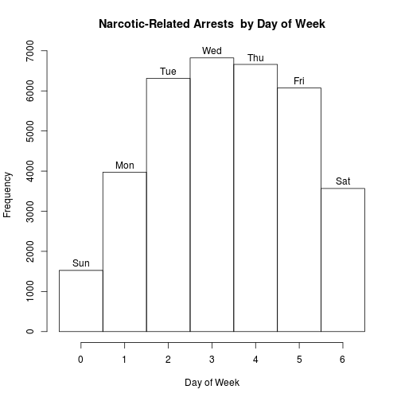

```r
# Plot histogram of narcotic-related arrests over the week
hist_dayofweek(narcotic_arrests$arrestDate, "Narcotic-Related Arrests")
```

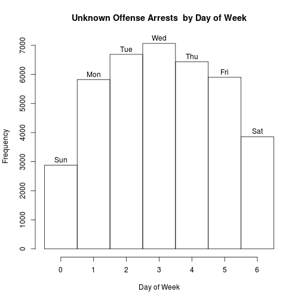

[output not shown]

```r
# Plot histogram of unknown-offense arrests over the week
hist_dayofweek(unknown_arrests$arrestDate, "Unknown Offense Arrests")
```

```r
# Prepare the dataset of vacant buildings
vacant_tab <- read.csv("Vacant_Buildings.csv", stringsAsFactors = FALSE)

# prepare long/lat comlumns
tmp = gsub("\\)", "", gsub("\\(", "", vacant_tab$Location))
```

```r
tmp = strsplit(tmp, split = ",")
vacant_tab$lon = as.numeric(sapply(tmp, function(x) x[2]))
vacant_tab$lat = as.numeric(sapply(tmp, function(x) x[1]))

# Plot the geographical distribution of vacant buildings vs. arrests
library(ggplot2)
library(ggmap)

# Function to plot datapoints using GoogleMaps API
plot_map <- function(map, dataPoints, dataPoints2) {
    googleMap = ggmap(map)
    googleMap = googleMap + geom_point(data = dataPoints, aes(x = lon, y = lat),
        color = "black", alpha = 0.1, size = 3)
    if (!missing(dataPoints2)) {
        googleMap = googleMap + geom_point(data = dataPoints2, aes(x = lon,
            y = lat), color = "yellow", alpha = 0.1, size = 1.5)
    }
    googleMap
}

# Get Baltimore city map from GoogleMaps
map = get_map(location = c(lon = -76.62, lat = 39.3), zoom = 12, maptype = "terrain")
```

```
## Google Maps API Terms of Service : http://developers.google.com/maps/terms
```

[figure not shown]

```r
# Plot violence-related arrests vs. vacant buildings locations
plot_map(map, violent_arrests, vacant_tab)
```

[figure not shown]

```r
# Plot narcotic-related arrests vs. vacant buildings locations
plot_map(map, narcotic_arrests, vacant_tab)
```

What did you observe?:

```
1. For Q1:
  - As observed from the figures, violence-related arrests are high in weekends (with a peak on Saturday) as anticipated.
  - Both narcotic-related arrests and arrests with unknown-offense have their peak in the middle of the week, with a lower rate on weekends.
  - As the number of records for narcotic-related and unknown offense arrests are much higher than violence-related arrests, the overall total crime rate has its peak on Wednesday, not in weekends.

2. For Q2:
  As predicted, the figures show that the vacant buildings in a neighborhood are correlated with its crime rate, with a bit more correlation with neighborhoods where arrests due to violence occurred than the narcotic-related arrests.
```

#### Xiyang Dai

What question are you asking?:

Q1. Is there a relationship between arrest time and crime type?

Q2. Is there a relationship between arrest time and arrest location (longitude, latitude)?

What is the code you use to answer it?:

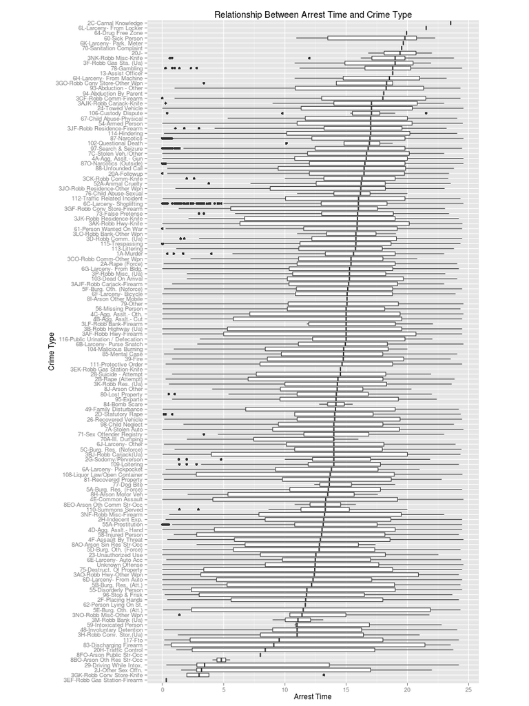

```r
library(ggmap)
library(ggplot2)

# Define function that converts time to numerical value for calculation
time2num = function(x) {
    tmp = as.numeric(gsub("\\:", "", x))
    x = tmp/100 + tmp%%100/60
}

# Get subtable from the original table
arrest_tab_tmp1 = subset(arrest_tab, incidentOffense != "", select = c(arrestTime,
    incidentOffense))
arrest_tab_tmp1 = arrest_tab_tmp1[complete.cases(arrest_tab_tmp1), ]
arrest_tab_tmp1$arrestTime = sapply(arrest_tab_tmp1$arrestTime, time2num)

# Plot the the relationship between arrest time and crime type, reorder them
# based on the median of arrest time value
arrest_tab_tmp1$incidentOffense = with(arrest_tab_tmp1, reorder(incidentOffense,
    arrestTime, median))
qplot(factor(arrest_tab_tmp1$incidentOffense), arrest_tab_tmp1$arrestTime, main = "Relationship Between Arrest Time and Crime Type",
    xlab = "Crime Type", ylab = "Arrest Time", geom = "boxplot", asp = 2) +
    coord_flip()
```

```r
# Get subtable from the original table
arrest_tab_tmp2 = subset(arrest_tab, select = c(arrestTime, lon, lat))
arrest_tab_tmp2 = arrest_tab_tmp2[complete.cases(arrest_tab_tmp2), ]
arrest_tab_tmp2$arrestTime = sapply(arrest_tab_tmp2$arrestTime, time2num)

# Shift time axis to start at 6am for better representation
shift_axis_shift = function(x) {
    if (x < 6) {
        x = x + 24
    } else {
        x = x
    }
}
arrest_tab_tmp2$arrestTime = sapply(arrest_tab_tmp2$arrestTime, shift_axis_shift)

# Cut number into bins for color visualization
rg_pal = colorRampPalette(c(c("light green", "yellow", "red")), bias = 1)
a_color = rg_pal(12)[as.numeric(cut(arrest_tab_tmp2$arrestTime, breaks = 12))]

# Get Baltemore map from Google Map
map = get_map(location = c(lon = -76.62, lat = 39.3), zoom = 12, maptype = "roadmap")
```

```
## Google Maps API Terms of Service : http://developers.google.com/maps/terms
```

```r
plt = ggmap(map)

# Visualize arrest time on map
plt = plt + geom_point(data = arrest_tab_tmp2, aes(x = arrest_tab_tmp2$lon,
    y = arrest_tab_tmp2$lat), color = a_color, alpha = 0.1)
plt = plt + guides(title = "Arrest Time", fill = guide_colorbar())
print(plt)
```

[figure not shown]

[figure not shown]

[figure not shown]

What did you observe?

Q2: It seems that there is a relationship between arrest time and arrest location. In places near the downtown, crimes trend to happen in night. In places far from downtown, crimes trend to happen in daytime. But this relationship still needs to be further analyzed commbing with specific geographic features.

#### Ruofei Du

What question are you asking?:

```
Is there a relationship between top crime types and age of the criminals? For instance, the younger criminals tend to commit more aggressive offence while the older tend to commit more stealthy offence.
```

What is the code you use to answer it?:

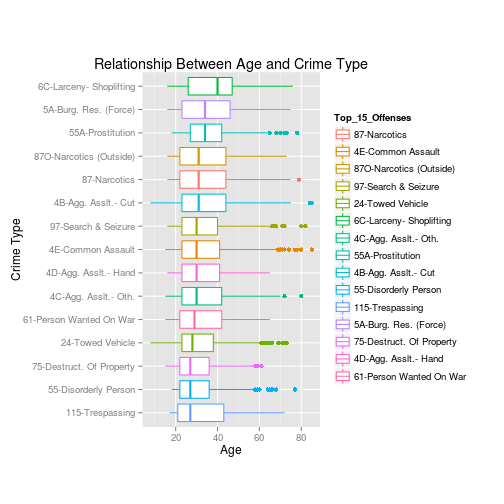

```r
# Remove the data with unknown offense or other type
arrestData <- subset(arrest_tab, age > 0 & incidentOffense != "Unknown Offense" &
    incidentOffense != "79-Other")
arrestData <- subset(arrestData, select = c(age, incidentOffense))

# Calculate the frequency of each crime type
offenseFreq <- table(arrestData$incidentOffense)
offenseFreq <- sort(offenseFreq, decreasing = TRUE)
N <- 15
topN <- data.frame(IncidentOffense = names(offenseFreq[1:N]), Freq = as.integer(offenseFreq[1:N]))
arrestData$topIncident <- sapply(arrestData$incidentOffense, function(x) {
    id <- 0
    for (y in names(offenseFreq[1:N])) {
        id <- id + 1
        if (x == y) {
            return(id)
        }
    }
    return(-1)
})
arrestData <- subset(arrestData, arrestData$topIncident != -1)
# Sort y axis by median of age; sort color by frequency
arrestData$incidentOffense = with(arrestData, reorder(incidentOffense, age,
    median))
arrestData$topOffense = with(arrestData, reorder(incidentOffense, topIncident,
    median))
Top_15_Offenses <- arrestData$topOffense
qplot(factor(arrestData$incidentOffense), arrestData$age, main = "Relationship Between Age and Crime Type",
    xlab = "Crime Type", ylab = "Age", geom = "boxplot", asp = 2, col = Top_15_Offenses) +
    coord_flip()
```

What did you observe?:

```
There's indeed a weak relationship between age and criminal type. The older criminals tend to commit crimes with less violence such as shop lifting and burglary. E.G. the median of shoplifting criminals is of age 40; the younger criminals ten to commit crimes with more violence and sabotage such as trespassing, disorder, destrction of property.

However, the age range of criminals can be adolescents to relatively old poeple. Few people commit destrction of property after the age of 60.
```

#### Will Armstrong

What question are you asking?: Is the difference in arrest numbers between “black” and “white” races due to population demographics?

What is the code you use to answer it?:

```r
#### Plot distribution of race for arrests based on neighborhood, based on code
#### by Ben Klimowski and Jon Fetter-Degges
total <- table(arrest_tab$neighborhood[arrest_tab$neighborhood != ""])
black.arrests <- arrest_tab$neighborhood[arrest_tab$race == "B"]
black <- table(black.arrests[black.arrests != ""])
white.arrests <- arrest_tab$neighborhood[arrest_tab$race == "W"]
white <- table(white.arrests[white.arrests != ""])

# 0-fill unused neighborhoods and resort
black[names(total)[!(names(total) %in% names(black))]] <- 0
black <- black[order(names(black))]
white[names(total)[!(names(total) %in% names(white))]] <- 0
white <- white[order(names(white))]

# Combine into data frame
df <- data.frame(total)
df$black <- black
df$white <- white
df <- df[order(df$Freq, df$black, df$white), ]
df$other <- df$Freq - df$black - df$white

#### Load population demographics
census_tab <- read.csv("Census_Demographics_2010.csv", stringsAsFactors = FALSE)

grepFun <- function(neighborhood) {
    ns <- unlist(strsplit(neighborhood, "/"))
    gr <- grep(ns[1], census_tab$CSA2010)
    index <- 0
    if (any(gr))
        index <- gr[1] else if (length(ns) > 1) {
        gr <- grep(ns[2], census_tab$CSA2010)
        if (any(gr))
            index <- gr[1]
    }
    index
}

# Look up census information for each neighborhood
df$census_ind <- apply(as.matrix(df$Var1), 1, grepFun)
# Remove neighborhoods not found in census
df <- df[df$census_ind > 0, ]
df$peraa <- census_tab$peraa10[df$census_ind]
df$perwhite <- census_tab$perwhite10[df$census_ind]
df$expected_b <- df$peraa * (df$Freq/100)
```

```
## Error: non-numeric argument to binary operator
```

```r
df$expected_w <- df$perwhite * (df$Freq/100)
```

```
## Error: non-numeric argument to binary operator
```

```r
#### Plot Results

rm(total, black, black.arrests, white, white.arrests, census_tab)
# Generate a plot of neighborhoods with the racial distribution of, along
# with points for the expected values.
old_par <- par(no.readonly = TRUE)
par(las = 2, mar = c(4, 9, 3, 2) + 0.1)
toPlot <- df$Freq > 600
df.bar <- barplot(t(as.matrix(df[toPlot, 3:4])), names.arg = df$Var1[toPlot],
    horiz = TRUE, col = c("green", "red"), cex.names = 0.7, main = "Race of Arrests by Neighborhood")
points(x = df$expected_b[toPlot], y = df.bar, col = "blue", pch = 18)
```

```
## Error: 'x' and 'y' lengths differ
```

```r
points(x = df$expected_w[toPlot] + df$black[toPlot], y = df.bar, col = "black",
    pch = 18)
```

```
## Error: 'x' and 'y' lengths differ
```

```r
legend(2000, 5, legend = c("black", "white", "expected black", "expected white"),
    fill = c("green", "red", "blue", "black"), cex = 0.7)
```

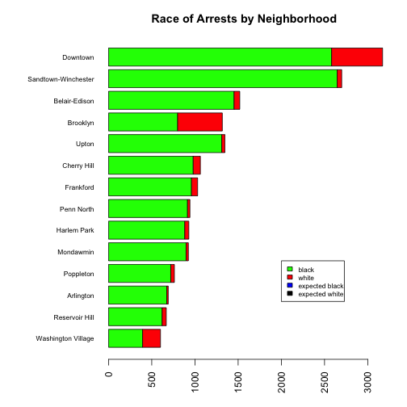

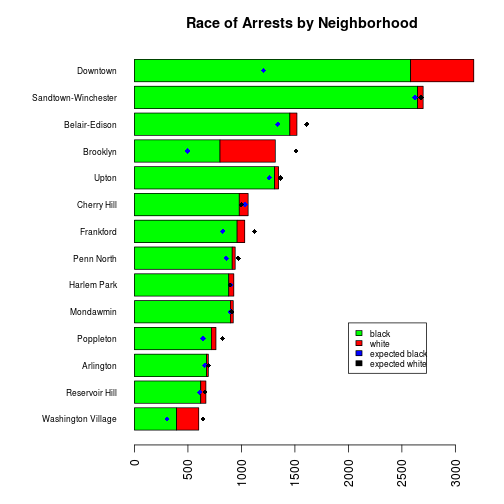

# What did you observe?

Here I am making a big assumption that people tend to get arrested in the same neighborhood in which they live. Therefore the results may not apply as well in a neighborhood like “Downtown” where more people commute to the neighborhood than live there. For about half of the listed neighborhoods, black arrests are higher than mere population demographics would predict and white arrests are lower. This could be due to a variety of factors, not least of which is potential racism among the police force. The other half follow the expected results very well, and Cherry Hill even reverses the finding. Therefore I conclude that race of arrest is at leasty partially influenced by factors other than from population demographics.

### Bharat and Michael

What question are you asking?

What is the code you used to answer it?

```r
library(FSelector)
arrest_tab = read.csv("BPD_Arrests.csv", stringsAsFactors = FALSE)
mod_arrest_tab <- arrest_tab
notneeded <- c("arrest", "charge", "chargeDescription", "Location.1", "arrestLocation",
    "incidentOffense", "post")
mod_arrest_tab <- mod_arrest_tab[, !(names(mod_arrest_tab) %in% notneeded)]
mod_arrest_tab$arrestDate <- unlist(lapply(mod_arrest_tab$arrestDate, function(x) substr(x,
    1, 2)))
mod_arrest_tab$arrestTime <- unlist(lapply(mod_arrest_tab$arrestTime, function(x) substr(x,
    1, 2)))

wage <- information.gain(age ~ ., mod_arrest_tab)
wsex <- information.gain(sex ~ ., mod_arrest_tab)
wrace <- information.gain(race ~ ., mod_arrest_tab)
wincidentLocation <- information.gain(incidentLocation ~ ., mod_arrest_tab)
wdistrict <- information.gain(district ~ ., mod_arrest_tab)
wneighborhood <- information.gain(neighborhood ~ ., mod_arrest_tab)
warrestDate <- information.gain(arrestDate ~ ., mod_arrest_tab)
warrestTime <- information.gain(arrestTime ~ ., mod_arrest_tab)

require(igraph)
# 1 - Age 2 - Sex 3 - Race 4 - Incident Location 5 - District 6 -
# Neighborhood 7 - Date 8 - Time
g1 <- graph(c(1, 2, 1, 3, 1, 4, 1, 5, 1, 6, 1, 7, 1, 8, 2, 3, 2, 4, 2, 5, 2,
    6, 2, 7, 2, 8, 3, 4, 3, 5, 3, 6, 3, 7, 3, 8, 4, 5, 4, 6, 4, 7, 4, 8, 5,
    6, 5, 7, 5, 8, 6, 7, 6, 8, 7, 8), directed = FALSE)
```

```
## Error: could not find function "graph"
```

```r
V(g1)$label <- c("Age", "Sex", "Race", "IncidentLocation", "District", "Neighborhood",
    "ArrestDate", "ArrestTime")
```

```
## Error: object 'g1' not found
```

```r
colors = heat.colors(1000)

# set colors for Age node
E(g1)[1]$color <- colors[999 - as.integer(200 * wage["sex", 1])]
```

```
## Error: object 'g1' not found
```

```r
E(g1)[2]$color <- colors[999 - as.integer(200 * wage["race", 1])]
```

```
## Error: object 'g1' not found
```

```r
E(g1)[3]$color <- colors[999 - as.integer(200 * wage["incidentLocation", 1])]
```

```
## Error: object 'g1' not found
```

```r
E(g1)[4]$color <- colors[999 - as.integer(200 * wage["district", 1])]
```

```
## Error: object 'g1' not found
```

```r
E(g1)[5]$color <- colors[999 - as.integer(200 * wage["neighborhood", 1])]
```

```
## Error: object 'g1' not found
```

```r
E(g1)[6]$color <- colors[999 - as.integer(200 * wage["arrestDate", 1])]
```

```
## Error: object 'g1' not found
```

```r
E(g1)[7]$color <- colors[999 - as.integer(200 * wage["arrestTime", 1])]
```

```
## Error: object 'g1' not found
```

```r
# set colors for Sex node
E(g1)[8]$color <- colors[999 - as.integer(200 * wsex["race", 1])]
```

```
## Error: object 'g1' not found
```

```r
E(g1)[9]$color <- colors[999 - as.integer(200 * wsex["incidentLocation", 1])]
```

```
## Error: object 'g1' not found
```

```r
E(g1)[10]$color <- colors[999 - as.integer(200 * wsex["district", 1])]
```

```
## Error: object 'g1' not found
```

```r
E(g1)[11]$color <- colors[999 - as.integer(200 * wsex["neighborhood", 1])]
```

```
## Error: object 'g1' not found
```

```r
E(g1)[12]$color <- colors[999 - as.integer(200 * wsex["arrestDate", 1])]
```

```
## Error: object 'g1' not found
```

```r
E(g1)[13]$color <- colors[999 - as.integer(200 * wsex["arrestTime", 1])]
```

```
## Error: object 'g1' not found
```

```r
# set colors for Race node
E(g1)[14]$color <- colors[999 - as.integer(200 * wrace["incidentLocation", 1])]
```

```
## Error: object 'g1' not found
```

```r
E(g1)[15]$color <- colors[999 - as.integer(200 * wrace["district", 1])]
```

```
## Error: object 'g1' not found
```

```r
E(g1)[16]$color <- colors[999 - as.integer(200 * wrace["neighborhood", 1])]
```

```
## Error: object 'g1' not found
```

```r
E(g1)[17]$color <- colors[999 - as.integer(200 * wrace["arrestDate", 1])]
```

```
## Error: object 'g1' not found
```

```r
E(g1)[18]$color <- colors[999 - as.integer(200 * wrace["arrestTime", 1])]
```

```
## Error: object 'g1' not found
```

```r
E(g1)[19]$color <- colors[999 - as.integer(200 * wincidentLocation["district",
    1])]
```

```
## Error: object 'g1' not found
```

```r
E(g1)[20]$color <- colors[999 - as.integer(200 * wincidentLocation["neighborhood",
    1])]
```

```
## Error: object 'g1' not found
```

```r
E(g1)[21]$color <- colors[999 - as.integer(200 * wincidentLocation["arrestDate",
    1])]
```

```
## Error: object 'g1' not found
```

```r
E(g1)[22]$color <- colors[999 - as.integer(200 * wincidentLocation["arrestTime",
    1])]
```

```
## Error: object 'g1' not found
```

```r
E(g1)[23]$color <- colors[999 - as.integer(200 * wdistrict["neighborhood", 1])]
```

```
## Error: object 'g1' not found
```

```r
E(g1)[24]$color <- colors[999 - as.integer(200 * wdistrict["arrestDate", 1])]
```

```
## Error: object 'g1' not found
```

```r
E(g1)[25]$color <- colors[999 - as.integer(200 * wdistrict["arrestTime", 1])]
```

```
## Error: object 'g1' not found
```

```r
E(g1)[26]$color <- colors[999 - as.integer(200 * wneighborhood["arrestDate",
    1])]
```

```
## Error: object 'g1' not found
```

```r
E(g1)[27]$color <- colors[999 - as.integer(200 * wneighborhood["arrestTime",
    1])]
```

```
## Error: object 'g1' not found
```

```r
E(g1)[28]$color <- colors[999 - as.integer(200 * warrestDate["arrestTime", 1])]
```

```
## Error: object 'g1' not found
```

```r
plot(g1)
```

[output not shown]

```
## Error: object 'g1' not found
```

```r
# 1 - Age 2 - Sex 3 - Race 4 - Date 5 - Time
g2 <- graph(c(1, 2, 1, 3, 1, 4, 1, 5, 2, 3, 2, 4, 2, 5, 3, 4, 3, 5, 4, 5), directed = FALSE)
```

```
## Error: could not find function "graph"
```

```r
V(g2)$label <- c("Age", "Sex", "Race", "ArrestDate", "ArrestTime")
```

```
## Error: object 'g2' not found
```

```r
# set colors for Age node
E(g2)[1]$color <- colors[999 - as.integer(60000 * wage["sex", 1])]
```

```
## Error: object 'g2' not found
```

```r
E(g2)[2]$color <- colors[999 - as.integer(60000 * wage["race", 1])]
```

```
## Error: object 'g2' not found
```

```r
E(g2)[3]$color <- colors[999 - as.integer(60000 * wage["arrestDate", 1])]
```

```
## Error: object 'g2' not found
```

```r
E(g2)[4]$color <- colors[999 - as.integer(60000 * wage["arrestTime", 1])]
```

```
## Error: object 'g2' not found
```

```r
# set colors for Sex node
E(g2)[5]$color <- colors[999 - as.integer(60000 * wage["race", 1])]
```

```
## Error: object 'g2' not found
```

```r
E(g2)[6]$color <- colors[999 - as.integer(60000 * wage["arrestDate", 1])]
```

```
## Error: object 'g2' not found
```

```r
E(g2)[7]$color <- colors[999 - as.integer(60000 * wage["arrestTime", 1])]
```

```
## Error: object 'g2' not found
```

```r
# set colors for Race node
E(g2)[8]$color <- colors[999 - as.integer(60000 * wage["arrestDate", 1])]
```

```
## Error: object 'g2' not found
```

```r
E(g2)[9]$color <- colors[999 - as.integer(60000 * wage["arrestTime", 1])]
```

```
## Error: object 'g2' not found
```

```r
# set colors for Date node
E(g2)[9]$color <- colors[999 - as.integer(60000 * wage["arrestTime", 1])]
```

```
## Error: object 'g2' not found
```

```r
plot(g2)
```

[output not shown]

```
## Error: object 'g2' not found
```

#### Shangfu Peng

What question are you asking?:

```
Which types of arrested crimes can benefit from CCTV cameras? Is there any relationship between the number of CCTV cameras and the number of arrests on specific incident offense? In addition, what is the difference of the performance on sex?
```

What is the code you use to answer it?:

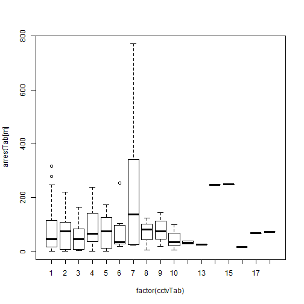

```r
narcotics <- c("87-Narcotics", "87O-Narcotics (Outside)", "97-Search & Seizure")
violent <- c("1A-Murder", "2A-Rape (Force)", "2B-Rape (Attempt)", "3AF-Robb Hwy-Firearm",
    "3AJF-Robb Carjack-Firearm", "3AJK-Robb Carjack-Knife", "3AK-Robb Hwy-Knife",
    "3AO-Robb Hwy-Other Wpn", "3CF-Robb Comm-Firearm", "3CK-Robb Comm-Knife",
    "3CO-Robb Comm-Other Wpn", "3EF-Robb Gas Station-Firearm", "3EK-Robb Gas Station-Knife",
    "3GF-Robb Conv Store-Firearm", "3GK-Robb Conv Store-Knife", "3GO-Robb Conv Store-Other Wpn",
    "3JF-Robb Residence-Firearm", "3JK-Robb Residence-Knife", "3JO-Robb Residence-Other Wpn",
    "3LF-Robb Bank-Firearm", "3FO-RObb Bank-Other Wpn", "3NF-Robb Misc-Firearm",
    "3NK-Robb Misc-Knife", "3NO-Robb Misc-Other Wpn", "4A-Agg. Asslt.- Gun",
    "4B-Agg. Asslt.- Cut", "4C-Agg. Asslt.- Oth.", "4D-Agg. Asslt.- Hand")


IncidentViaCCTV <- function(offenses, sexual) {
    subsetvio = subset(arrest_tab, arrest_tab$incidentOffense %in% offenses)
    if (sexual == "M" || sexual == "F")
        subsetsex = subset(subsetvio, subsetvio$sex == sexual) else subsetsex = subsetvio

    latRange = range(arrest_tab$lat, na.rm = TRUE)
    lonRange = range(arrest_tab$lon, na.rm = TRUE)
    latGrid = seq(min(latRange), max(latRange), len = 50)
    lonGrid = seq(min(lonRange), max(lonRange), len = 50)
    latFac = as.numeric(cut(subsetsex$lat, breaks = latGrid))
    lonFac = as.numeric(cut(subsetsex$lon, breaks = lonGrid))

    gridFac = (latFac - 1) * length(latGrid) + (lonFac - 1)

    latFac = as.numeric(cut(cctv_tab$lat, breaks = latGrid))
    lonFac = as.numeric(cut(cctv_tab$lon, breaks = lonGrid))
    cctvGridFac = (latFac - 1) * length(latGrid) + (lonFac - 1)

    arrestTab = table(gridFac)
    cctvTab = table(cctvGridFac)
    m = match(names(cctvTab), names(arrestTab))
    plot(arrestTab[m] ~ factor(cctvTab))
}

IncidentViaCCTV(narcotics, "M")
```

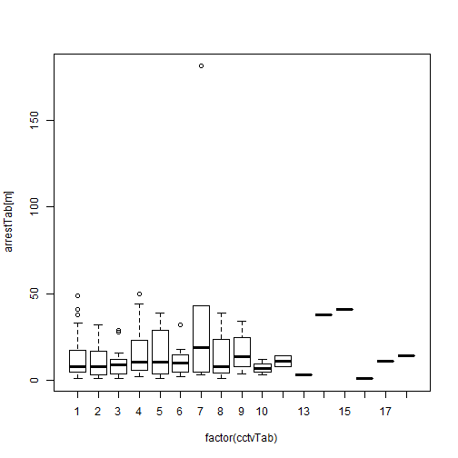

```r
IncidentViaCCTV(narcotics, "F")
```

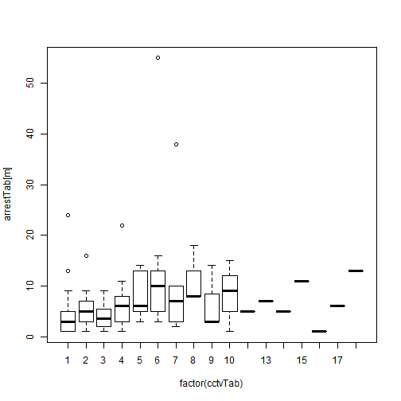

```r
IncidentViaCCTV(violent, "M")
```

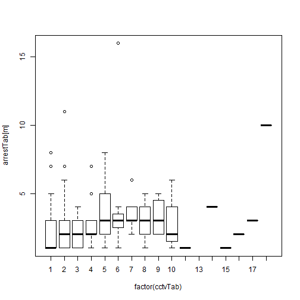

```r
IncidentViaCCTV(violent, "F")
```

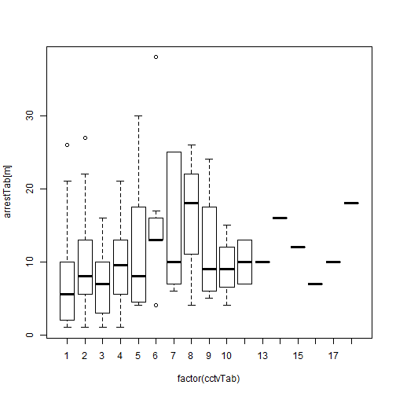

```r
IncidentViaCCTV(c("4E-Common Assault"), "M")
```

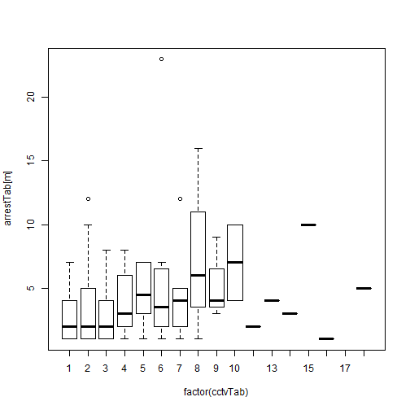

```r
IncidentViaCCTV(c("4E-Common Assault"), "F")
```

What did you observe?:

```
From previous "challenge" example, we know that the relationship between the number of CCTV cameras and the number of arrests is not obvious. However, I guess that there should be some certain incident offenses that woule benefit from CCTV caremas. (Otherwise, we can give up CCTV caremas.)

First I tested on narcotics offenses. It is not influensed by the number of cameras. I guess it is because most people have drug in the houses, such that would not be photoed by cameras.

Second I tested on violent crimes. Ignoing the small cases, the number of arrested crimes roughly increases as the number of caremas, especially on female. Obviously, CCTV cameras can catch violent crimes.

Furthermore, I tested on the certain offenses, "4E-Common Assault". The relationship is more obvious.

So using this function, we can know the which types of crimes would benefit from CCTV caremas.
```

#### Phil Nguyen

Question: What is the distribution of arrest time for each neighborhood?

Code I use:

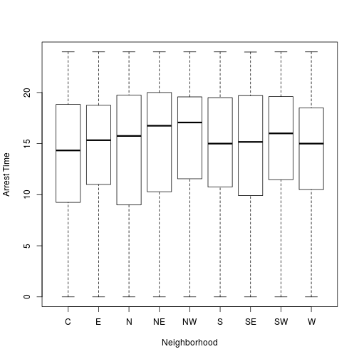

```r
# convert arrest time to numeric, e.g. 11:45 -> 11.75
time.to.num <- function(s) {
    x <- as.numeric(gsub(":", "", s))
    (x%/%100) + (x%%100)/60
}

# abbreviate district names
abbrev <- function(s) {
    gsub("CENTRAL", "C", gsub("EASTERN", "E", gsub("WESTERN", "W", gsub("NORTHERN",
        "N", gsub("NORTHWESTERN", "NW", gsub("SOUTHEASTERN", "SE", gsub("SOUTHERN",
            "S", gsub("SOUTHWESTERN", "SW", gsub("NORTHEASTERN", "NE", s)))))))))
}

# filter out empty districts
dat <- arrest_tab[arrest_tab$district != "", ]

plot(time.to.num(dat$arrestTime) ~ factor(abbrev(dat$district)), xlab = "Neighborhood",
    ylab = "Arrest Time")
```

```r
# earliest and latest arrest time median
median(time.to.num(dat$arrestTime[dat$district == "NORTHWESTERN"]))
```

```
## [1] 17.07
```

```r
median(time.to.num(dat$arrestTime[dat$district == "CENTRAL"]))
```

```
## [1] 14.33
```

What I observed: Overall, more than half of the arrests happen between 10AM and 8PM. There is no siginificant difference between arrest time in different neighborhoods, although arrests happen slightly earlier in central and the southern areas compared to northern areas.